# NYPD Shooting Incident Analysis

Harjeet Singh

10/15/2023

The below code is loaded to effectively run the report.

```r
library(tidyverse)
library(lubridate)
```

This data gives specifics on every shooting incident that occured in New York City starting from 2006 until the end of the previous calandar year. This data is manually extracted every quarter and reviewed by the Office of Management Analysis and Planning before being posted on the NYPD websiite. This collection of data has taken alot of man hours to gather and speaks volume to the department as they keep track of all this data just so it could be viewable for the public in the future.

Each incident is broken down to the event, the location and time of occurance, and additional demographics that relates to the suspect and the victims involved. This data is a great resource to the public as they can draw conclusiosns and analyaze from this large data set.

## Input Data

Obtaining data from the website.

```r
NYPD_data_url <- "https://data.cityofnewyork.us/api/views/833y-fsy8/rows.csv?accessType=DOWNLOAD"
```

Analysing the data.

```r
NYPD_data <- read_csv(NYPD_data_url)
summary(NYPD_data)
```

```
##   INCIDENT_KEY        OCCUR_DATE         OCCUR_TIME           BORO
##  Min.   :  9953245   Length:27312       Length:27312      Length:27312
##  1st Qu.: 63860880   Class :character   Class1:hms        Class :character
##  Median : 90372218   Mode  :character   Class2:difftime   Mode  :character
##  Mean   :120860536                      Mode  :numeric
##  3rd Qu.:188810230
##  Max.   :261190187
##
##  LOC_OF_OCCUR_DESC     PRECINCT      JURISDICTION_CODE LOC_CLASSFCTN_DESC
##  Length:27312       Min.   :  1.00   Min.   :0.0000    Length:27312
##  Class :character   1st Qu.: 44.00   1st Qu.:0.0000    Class :character
##  Mode  :character   Median : 68.00   Median :0.0000    Mode  :character
##                     Mean   : 65.64   Mean   :0.3269
##                     3rd Qu.: 81.00   3rd Qu.:0.0000
##                     Max.   :123.00   Max.   :2.0000
##                                      NA's   :2
##  LOCATION_DESC      STATISTICAL_MURDER_FLAG PERP_AGE_GROUP
##  Length:27312       Mode :logical           Length:27312
##  Class :character   FALSE:22046             Class :character
##  Mode  :character   TRUE :5266              Mode  :character
##
##
##
##
##    PERP_SEX          PERP_RACE         VIC_AGE_GROUP        VIC_SEX
##  Length:27312       Length:27312       Length:27312       Length:27312
##  Class :character   Class :character   Class :character   Class :character
##  Mode  :character   Mode  :character   Mode  :character   Mode  :character
##
##
##
##
##    VIC_RACE           X_COORD_CD        Y_COORD_CD        Latitude
##  Length:27312       Min.   : 914928   Min.   :125757   Min.   :40.51
##  Class :character   1st Qu.:1000028   1st Qu.:182834   1st Qu.:40.67
##  Mode  :character   Median :1007731   Median :194487   Median :40.70
##                     Mean   :1009449   Mean   :208127   Mean   :40.74
##                     3rd Qu.:1016838   3rd Qu.:239518   3rd Qu.:40.82
##                     Max.   :1066815   Max.   :271128   Max.   :40.91
##                                                        NA's   :10
##    Longitude        Lon_Lat
##  Min.   :-74.25   Length:27312
##  1st Qu.:-73.94   Class :character
##  Median :-73.92   Mode  :character
##  Mean   :-73.91
##  3rd Qu.:-73.88
##  Max.   :-73.70
##  NA's   :10
```

## Tidy Data

Tidy the data by removing some columns and changing the format of others.

```r
NYPD <- NYPD_data %>%
  mutate(OCCUR_DATE = mdy(OCCUR_DATE)) %>%
  select(-c(INCIDENT_KEY, LOC_OF_OCCUR_DESC, JURISDICTION_CODE, X_COORD_CD, Y_COORD_CD, LOC_CLASSFCTN_DESC,
            Latitude, Longitude, Lon_Lat, LOCATION_DESC))
```

One area of interest was the time that shootings took place so new columns were added, one for the hour, one for the month, and one for the year of each event.

```r
NYPD <- NYPD %>%
  mutate(OCCUR_HOUR = hour(OCCUR_TIME)) %>%
  mutate(OCCUR_MONTH = month(OCCUR_DATE)) %>%
  mutate(OCCUR_YEAR = year(OCCUR_DATE))
```

Created a data set to explore the differences between boroughs

```r
NYPD_boro <- NYPD %>%
  group_by(BORO) %>%
  summarize(incidents = n()) %>%
  ungroup()
```

Created a data set to explore the differences by precinct

```r
NYPD_precinct <- NYPD %>%
  group_by(PRECINCT) %>%
  summarize(incidents = n()) %>%
  ungroup()
```

## Visualizations and Analysis

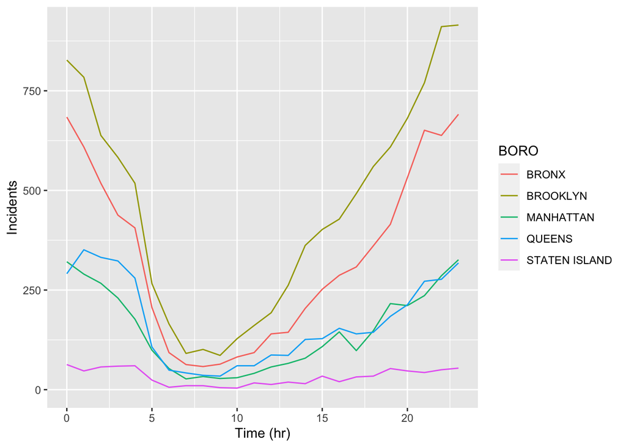

```r
NYPD %>%
  ggplot(aes(x = OCCUR_HOUR, color = BORO)) +
  geom_freqpoly(binwidth = 1) +
  xlim(0, 23) +
  labs(x = "Time (hr)", y = "Incidents" )
```

This graph shows the number of shootings by time of day. Most took place during overnight hours. From the data you can gather conclusions of when the peak and quiet times of crime are.

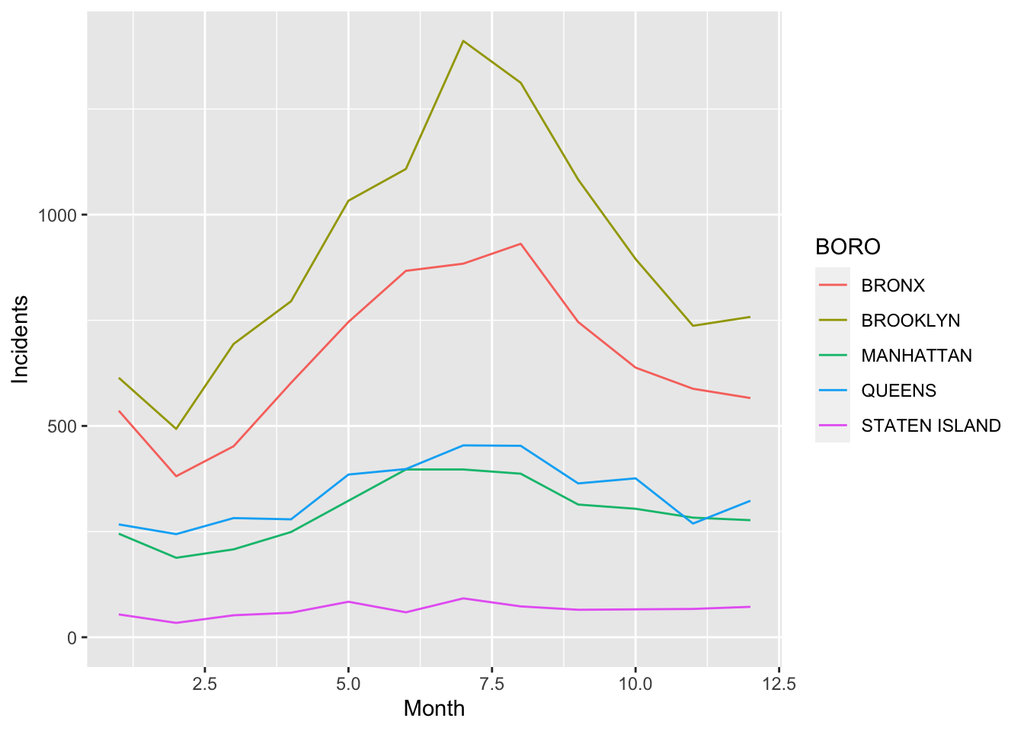

```r
NYPD %>%
  ggplot(aes(x = OCCUR_MONTH, color = BORO)) +
  geom_freqpoly(binwidth = 1) +
  xlim(1,12) +
  labs(x = "Month", y = "Incidents")
```

This graph clarifies the month each of the shootings occured. It can be seen that most shootings were happening during summer months.

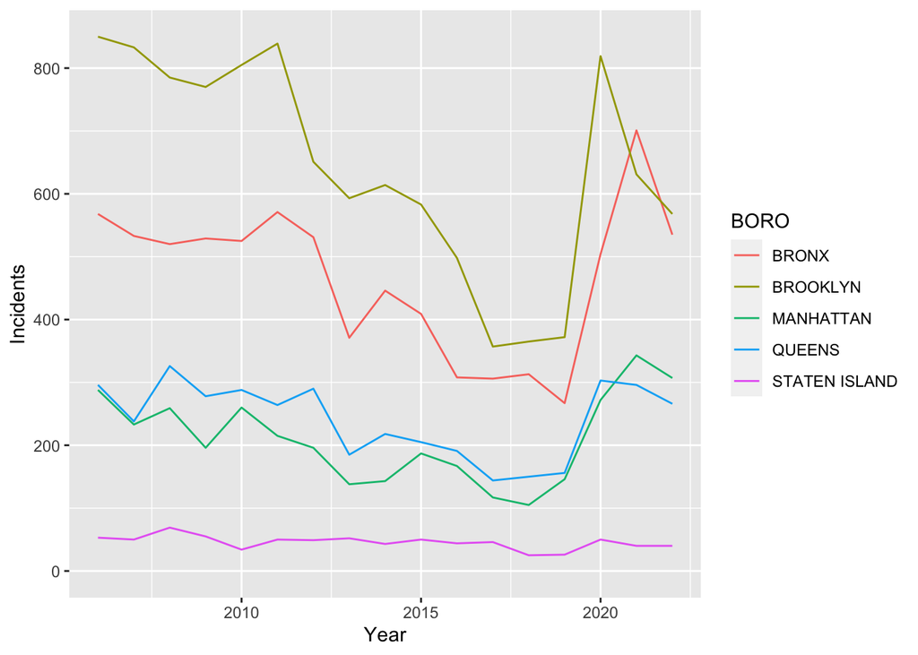

```r
NYPD %>%
  ggplot(aes(x = OCCUR_YEAR, color = BORO)) +
  geom_freqpoly(binwidth = 1) +
  xlim(2006,2022) +
  labs(x = "Year", y = "Incidents")
```

This graph shows the trend of crimes per year. It depicts a steady decline until 2020. The case number spiked when the Covid pandemic began along with the Black Lives Movement begining.

## Model

The following model shows how the death rate varies among the different boroughs with the time of day. The data is grouped by the hour of each occurrence then the number of shootings and deaths are summed up. To determine the death rate the number of deaths was divided by the number of shootings.

Its astonishing to see the breakdown and how the early morning hours tend to have the highest death rate.

```r
NYPD_boro_model <- NYPD %>%
  group_by(OCCUR_HOUR, BORO) %>%
  summarize(incidents = n(), deaths = sum(STATISTICAL_MURDER_FLAG)) %>%
  mutate(death_rate = round(deaths/incidents, digits = 2)) %>%
  ungroup()
```

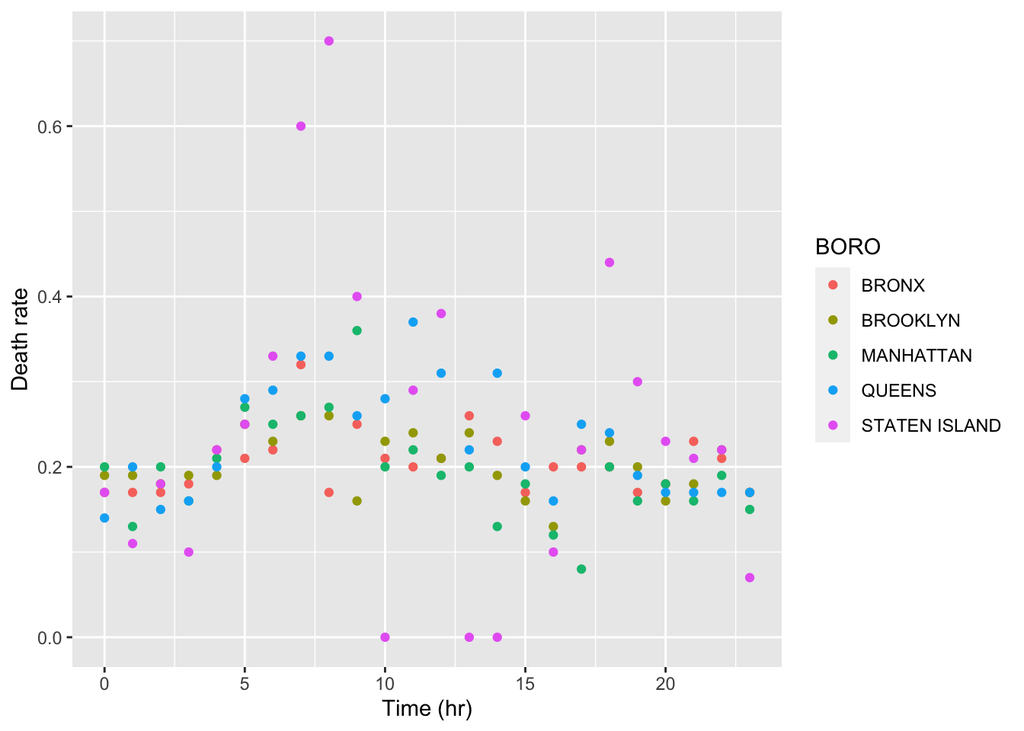

```r
NYPD_boro_model %>%
  ggplot(aes(x = OCCUR_HOUR, y = death_rate, color = BORO)) +
  geom_point() +
  labs(x = "Time (hr)", y = "Death rate")
```

## Bias

Many factors are be seen as bias but with this specific project one can be seen with the boroughs. In most of these graphs we see Brooklyn as being at the top for all shootings and crimes. If a person had no other information they would assume that this area is the most dangerous, hence the people that live there are also criminals. But other factos play a role into this statistic such as the population or even the tourist attraction. If more people are coming in and out of the borough than other areas it can consitute as a factor. Brooklyn might be the more dangerous borough but that does not mean everyone who lives in that particular area are involved in crime. Many times information at the surface level can be decieving, its only when we dive deeper we find the truth.